# R Notebook

The following code can be used to “cluster” or group data points within a data frame in such a way that the observations in each cluster are more similar to each other than observations in other clusters.

We will be calling an excel file from Github and reading it into R. For R to read the excel file we call-up the ‘rio’ package from the R Library. After reading in the data frame, we name it TM2_Data.

```r
library(rio)
#install_formats()
linkexcel = 'https://github.com/PUBPOL542G3/G3_Merge/blob/main/Triple_Merge.xlsx?raw=true'
TM2_Data=import(linkexcel)
```

Next, we want to explore some basic statistical information about each variable in our data frame. The first line of code creates a new data frame that only includes the columns ‘employment’, ‘CO2’ and ‘forest_area’ from our TM2_Data. The summary command displays the minimum, median, mean and maximum as well as the quartiles for each variable.

```r
DF_Clus=TM2_Data[,c('employment', 'CO2', 'forest_area')]
summary(DF_Clus)
```

```
##    employment          CO2           forest_area
##  Min.   :0.2920   Min.   : 0.0367   Min.   :     0.0
##  1st Qu.:0.5120   1st Qu.: 0.6380   1st Qu.:   591.9
##  Median :0.5820   Median : 2.4200   Median :  3184.0
##  Mean   :0.5798   Mean   : 4.4819   Mean   : 22754.3
##  3rd Qu.:0.6495   3rd Qu.: 5.9350   3rd Qu.: 14120.1
##  Max.   :0.8740   Max.   :41.3000   Max.   :814930.5
```

We need to rescale our DF_Clus data because the ranges of values for each of the variables in the data frame vary greatly. This code rescales the data into a common scale without distorting differences in the ranges of our variables. Using the summary command, we can once again see the minimum, median, mean, maximum and quartile values for each variable given the new common scale.

```r
DF_Clus=scale(DF_Clus)
summary(DF_Clus)
```

```
##    employment            CO2           forest_area
##  Min.   :-2.45229   Min.   :-0.7452   Min.   :-0.2795
##  1st Qu.:-0.57749   1st Qu.:-0.6444   1st Qu.:-0.2723
##  Median : 0.01904   Median :-0.3457   Median :-0.2404
##  Mean   : 0.00000   Mean   : 0.0000   Mean   : 0.0000
##  3rd Qu.: 0.59427   3rd Qu.: 0.2436   3rd Qu.:-0.1061
##  Max.   : 2.50742   Max.   : 6.1725   Max.   : 9.7319
```

When we created the DF_CLus data frame, we lost the country names associated with each observation. The first line of code below reassigns a country name to the appropriate indexes so that we can keep track of which country is associated with each data point as we continue our analysis. The second line of code displays the data with the newly reassigned indexes names.

```r
row.names(DF_Clus)=TM2_Data$country
head(DF_Clus)
```

```
##             employment         CO2 forest_area
## Afghanistan -0.7564448 -0.70746905 -0.26469096
## Albania     -0.9524473 -0.48315456 -0.26984147
## Algeria     -1.8046320 -0.11432656 -0.25550719
## Angola       1.2035799 -0.54686122  0.57282884
## Argentina   -0.1940029  0.02649867  0.07791965
## Armenia     -0.7734885 -0.47477211 -0.27548848
```

This code sets the starting number used to generate a sequence of random numbers. By starting with a set seed number, our code will run the same process every time. This ensures replicability of our results.

```r
set.seed(999)
```

In this code, we are creating a new data frame where the data points represent the pairwise distances between observations in the DF_Clus dataframe. We will use these pairwise distances to cluster the data points together.

```r
library(cluster)
DF_Clus_A=cluster::daisy(x=DF_Clus)
```

This code establishes the number of desired cluster groups (in this case 6 unique clusters). After designating the number of clusters, the pam function partitions (or clusters) the data.

```r
NumCluster=6
res.pam = pam(x=DF_Clus_A,
              k = NumCluster,
              cluster.only = F)
```

This code takes the clustered data results created above and adds them back into the original TM2_Data data frame.

```r
TM2_Data$pam=as.factor(res.pam$clustering)
```

To explore how our data was clustered, we used this code to query by cluster grouping. The code returns all of the countries in the designated cluster group (in this case cluster group 2).

```r
TM2_Data[TM2_Data$pam==2,'country']
```

```
##  [1] "Albania"                "Algeria"                "Armenia"
##  [4] "Bosnia and Herzegovina" "Comoros"                "Croatia"
##  [7] "Egypt"                  "Eswatini"               "Gabon"
## [10] "Greece"                 "Iran"                   "Iraq"
## [13] "Italy"                  "Jordan"                 "Lebanon"
## [16] "Lesotho"                "Libya"                  "Mauritania"
## [19] "Moldova"                "Montenegro"             "Morocco"
## [22] "North Macedonia"        "Palestine"              "Samoa"
## [25] "Serbia"                 "Somalia"                "South Africa"
## [28] "Spain"                  "Sudan"                  "Syria"
## [31] "Timor-Leste"            "Tunisia"                "Turkey"
## [34] "Yemen"
```

Similar to above, we can also query our data for a particular country. This code reutnrs the cluster group in which a country is located.

```r
TM2_Data[TM2_Data$country=="Peru",'pam']
```

```
## [1] 3
## Levels: 1 2 3 4 5 6
```

Using the table command, we can also see how many observations (i.e. countries) are present within each cluster. This code shows our six cluster groups with the corresponding number of countries under each group.

```r
table(TM2_Data$pam)
```

```
##
##  1  2  3  4  5  6
## 64 34 31 31 14  5
```

Factoextra is an R package for extracting outputs, creating visualizations and conducting multivariate data analyses. We call the facoextra package from the libary in the code below. This will enable the data analyses graphics below.

```r
library(factoextra)
```

This code uses a Silhouette analysis to measure how well the TM2_Data observations are clustered. It returns a visual displaying the six clusters.

```
##   cluster size ave.sil.width
## 1       1   64          0.34
## 2       2   34          0.47
## 3       3   31          0.45
## 4       4   31          0.35
## 5       5   14          0.09
## 6       6    5          0.22
```

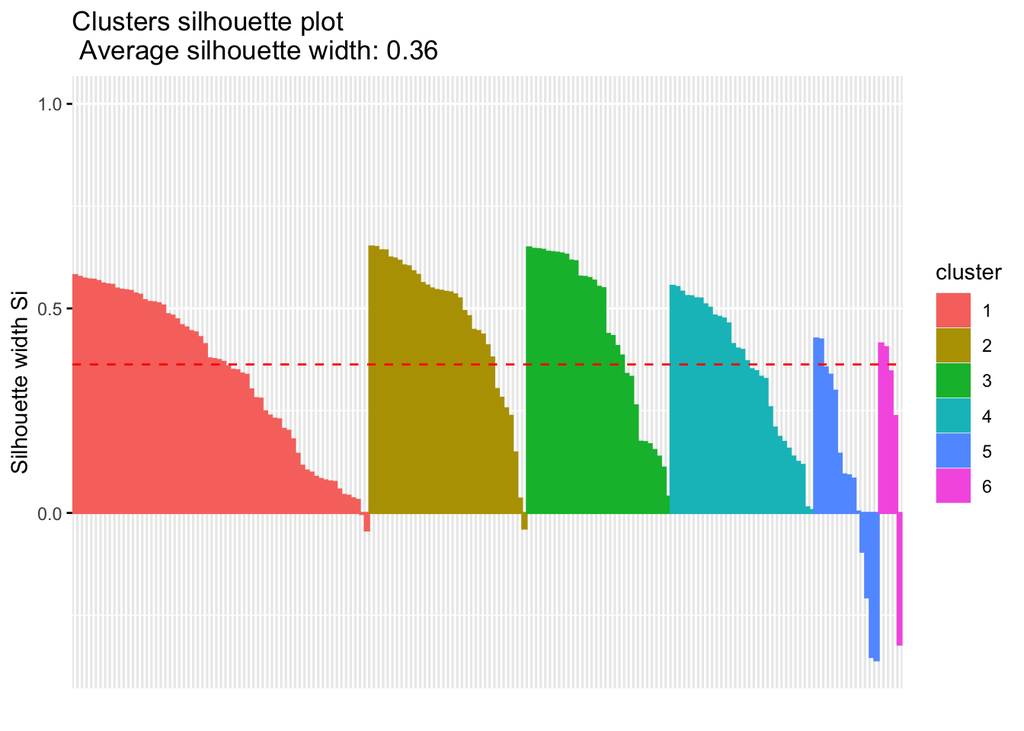

```r
fviz_silhouette(res.pam)
```

This code saves individual silhouette widths to a column in pamEval data frame.

```r
pamEval=data.frame(res.pam$silinfo$widths)
head(pamEval)
```

|  | cluster | neighbor | sil_width |
| --- | --- | --- | --- |
| Kenya | 1 | 4 | 0.5811865 |
| Haiti | 1 | 4 | 0.5768528 |
| Cote d'Ivoire | 1 | 4 | 0.5728278 |
| El Salvador | 1 | 4 | 0.5709328 |
| Guatemala | 1 | 4 | 0.5701248 |
| Tonga | 1 | 4 | 0.5667965 |

We used this code to call up all negative silhouettes (i.e. those silhouettes that are poorly clustered). This code helps us identify which countries are outliers in the respective cluster grouping.

```r
pamEval[pamEval$sil_width<0,]
```

|  | cluster | neighbor | sil_width |
| --- | --- | --- | --- |
| Mali | 1 | 3 | -0.002411265 |
| Lithuania | 1 | 4 | -0.042591940 |
| Armenia | 2 | 1 | -0.038114354 |
| Luxembourg | 5 | 4 | -0.094643668 |
| Iceland | 5 | 4 | -0.206127966 |
| Turkmenistan | 5 | 4 | -0.351860487 |
| Singapore | 5 | 4 | -0.359993339 |
| China | 6 | 4 | -0.321555116 |

This code prepares a bidemensional map of all indexed country names and saves the coordinates of this bidemensional map to the original data frame (i.e. TM2_Data).

```r
projectedData = cmdscale(DF_Clus_A, k=2)
TM2_Data$dim1 = projectedData[,1]
TM2_Data$dim2 = projectedData[,2]
```

This code plots the bidemensional map created above so that there is a visual representation, and we can, once again, clearly see outliers in the clustered data groups.

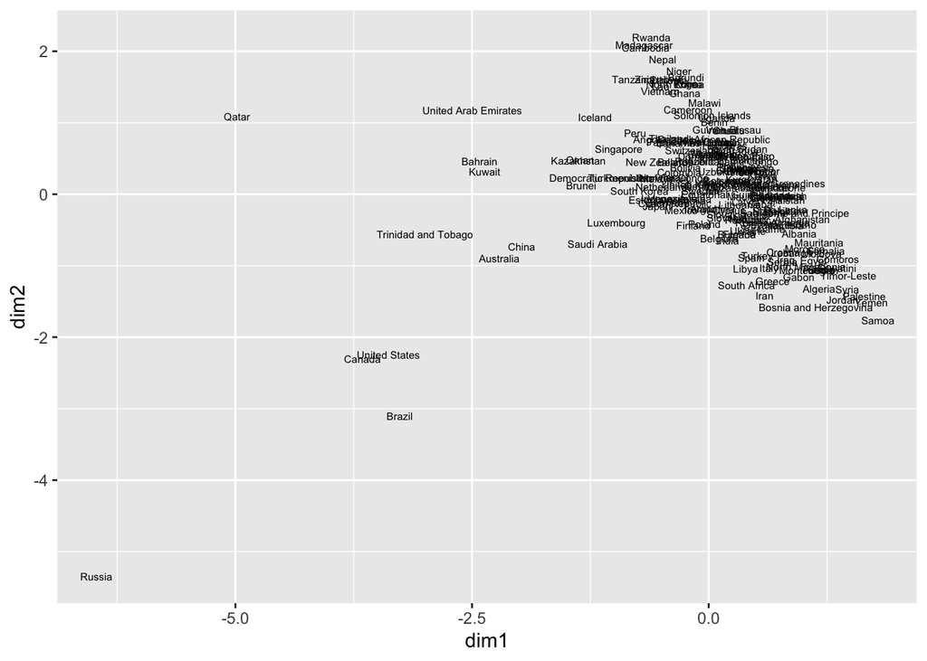

```r
base= ggplot(data=TM2_Data,
             aes(x=dim1, y=dim2,
                 label=country))
base + geom_text(size=2)
```

This code creates another visualization that plots all of the data points and color codes each point based off the cluster the point belongs to.

```r
pamPlot=base + labs(title = "PAM") + geom_point(size=2,
                                              aes(color=pam),
                                              show.legend = F)
```

Here we are displaying the color coded plot points that we created with the code above.

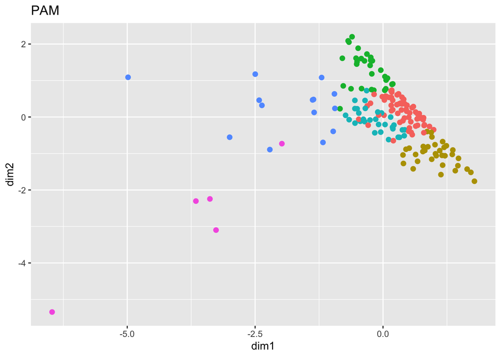

```r
pamPlot
```

This code calls up the ggrepel R package which helps us label data points with the corresponding country names without overlapping names or data points. The visualization below is the same as above just with added country names.

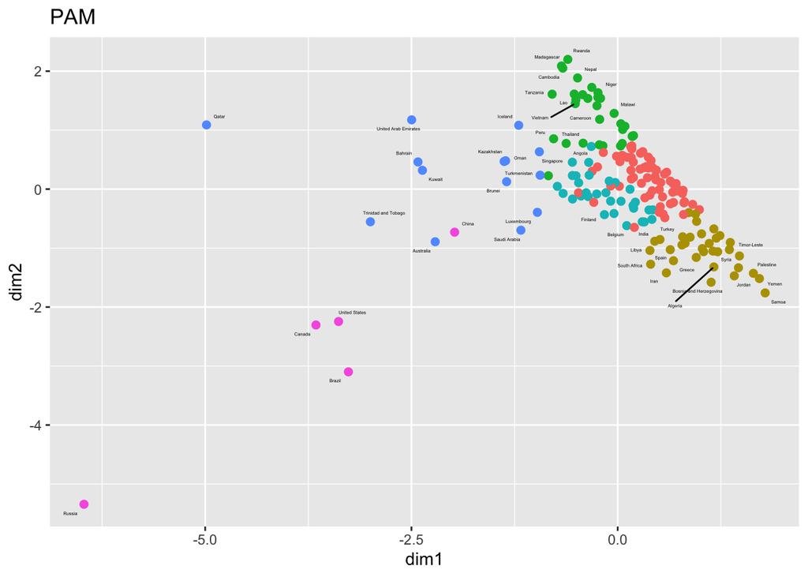

```r
library(ggrepel)
pamPlot + geom_text_repel(size=1,aes(label=country))
```

```r
max.overlaps = Inf
```

This code recreates the same visualization as above, however, the code below specifically annotates the outliers in the dataset in order to make them more easily identifiable.

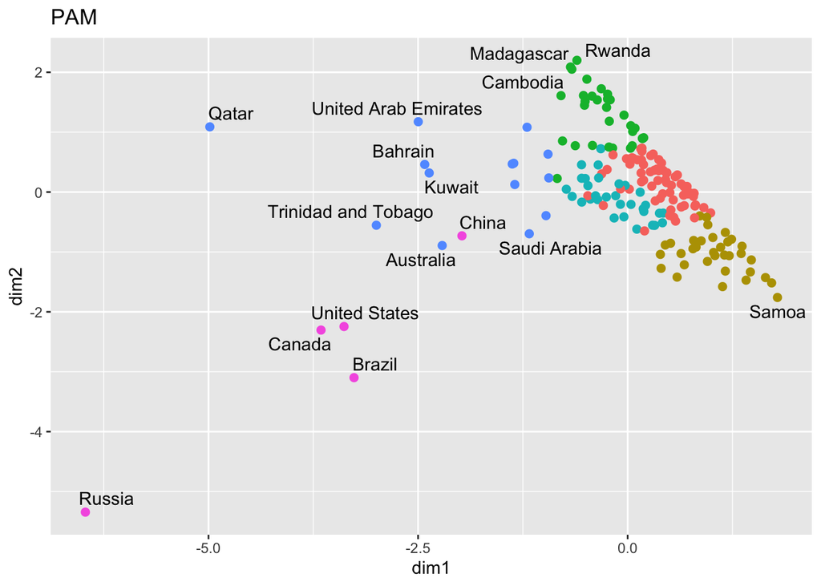

```r
LABEL=ifelse(TM2_Data$db==0,TM2_Data$country,"")

pamPlot + geom_text_repel(aes(label=country))
```